# Multivariate Statistics and Methodology using R

Confirmatory Factor Analysis

Aja Murray

Aja.Murray@ed.ac.uk

# This Week

- Techniques
  - Confirmatory Factor Analysis (CFA)
- Key Functions
  - cfa( ) from lavaan package
- Reading
  - lavaan tutorial: http://lavaan.ugent.be/tutorial/tutorial.pdf (sections 1-4)
  - lavaan paper: https://www.jstatsoft.org/article/view/v048i02
  - *Confirmatory Factor Analysis* chapter on Learn

# Learning Outcomes

[figure not shown]

- Know what it means to specify, estimate, and evaluate a CFA model
- Fit and interpret CFA models in R using the cfa( ) function
- Visualise CFA models using SEM diagrams

# Overview of this lecture

- Introduction to CFA
- Model Specification
- Model Identification
- Model Estimation
- Model Evaluation
- Model Modification

# Introduction to CFA

- Used to test a factor structure for a set of variables
- EFA is used when we have no fixed idea of our factor structure
- CFA is used to test a particular factor structure
- CFA tests how well our proposed factor structure fits the data
- Like EFA, CFA is a latent variable model
  - observed variables serve as **indicators** of underlying latent factors
- Unlike EFA, only specific loadings are included in the model

# The variance-covariance matrix

- Our starting point for CFA is the variance-covariance matrix for our items
- CFA models represent these variances/covariances in terms of a set of latent factors

```r
round(cov(agg.items),2)
```

```
##        item1 item2 item3 item4 item5 item6 item7 item8 item9 item10
## item1   0.98  0.56  0.47  0.44  0.59 -0.01  0.09  0.06  0.10   0.05
## item2   0.56  1.00  0.53  0.52  0.67  0.01  0.10  0.06  0.11   0.06
## item3   0.47  0.53  0.98  0.46  0.58  0.04  0.09  0.04  0.10   0.02
## item4   0.44  0.52  0.46  1.00  0.56  0.04  0.10  0.04  0.11   0.06
## item5   0.59  0.67  0.58  0.56  1.01  0.01  0.08  0.04  0.08   0.04
## item6  -0.01  0.01  0.04  0.04  0.01  1.03  0.58  0.60  0.43   0.45
## item7   0.09  0.10  0.09  0.10  0.08  0.58  0.98  0.81  0.58   0.60
## item8   0.06  0.06  0.04  0.04  0.04  0.60  0.81  1.02  0.61   0.64
## item9   0.10  0.11  0.10  0.11  0.08  0.43  0.58  0.61  0.98   0.45
## item10  0.05  0.06  0.02  0.06  0.04  0.45  0.60  0.64  0.45   1.01
```

# SEM Diagrams

[figure not shown]

# Exogenous versus endogeneous variables

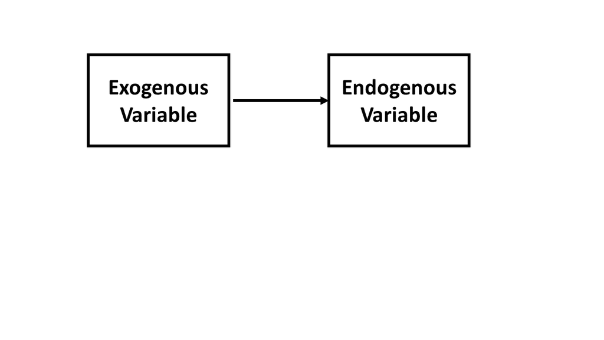

- **exogenous** variables receive input from no other variables
  - they emanate but are not on the end of single-headed arrow paths
  - they are the ‘independent variables’ or ‘predictors’
- **endogenous** variables receive input from other variables
  - they are on the end of single-headed arrow paths
  - they are the ‘dependent variables’ or ‘outcomes’
  - they may also be predictors of other variables in the model

# SEM diagram for a simple regression model

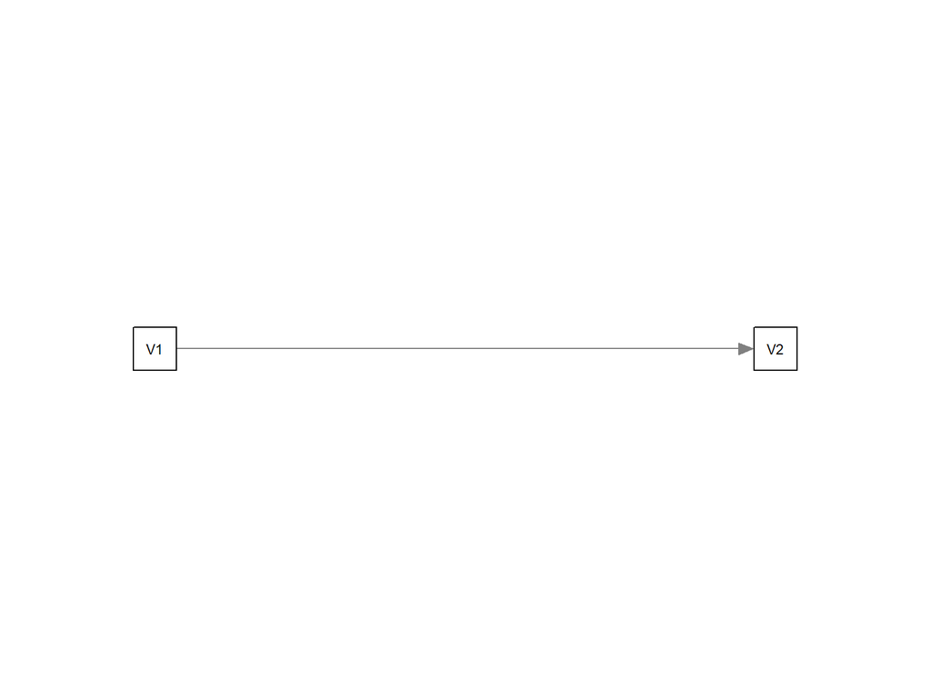

# SEM diagram for a covariance

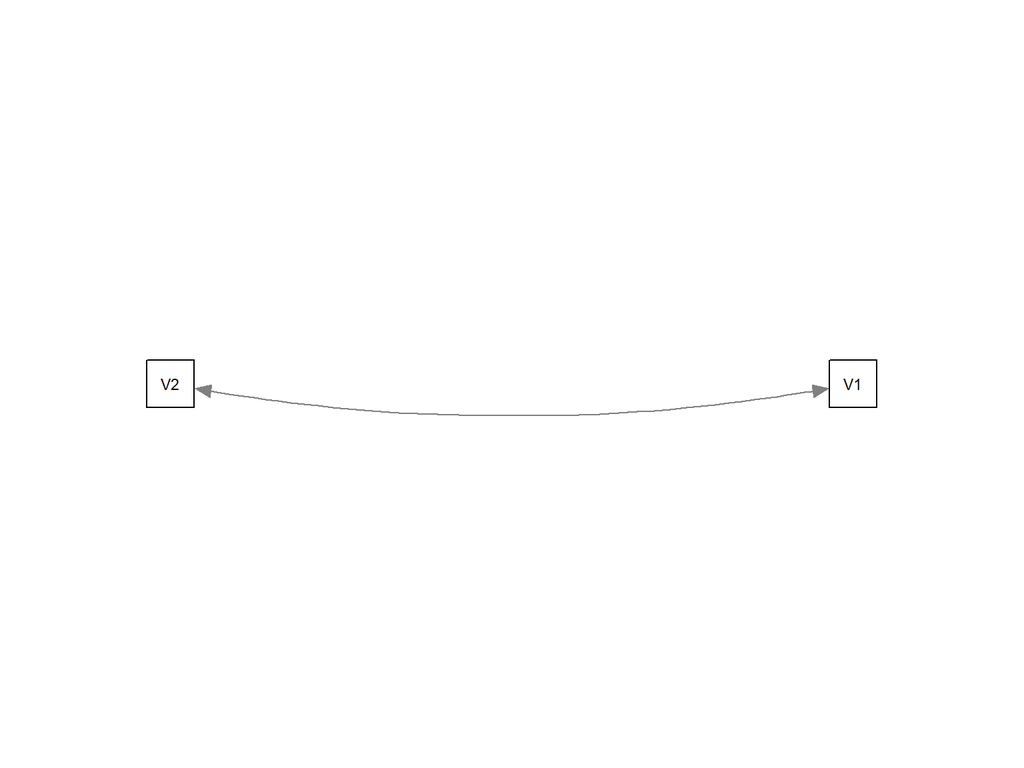

# SEM diagram for a path analysis model

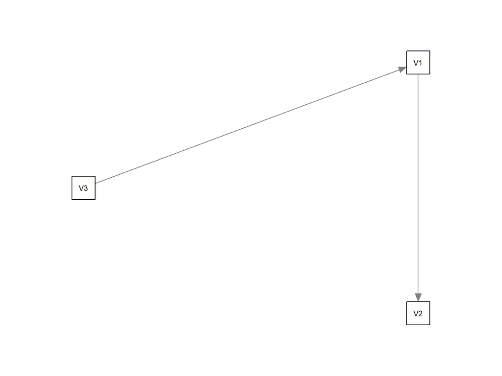

# SEM diagram for another path analysis model

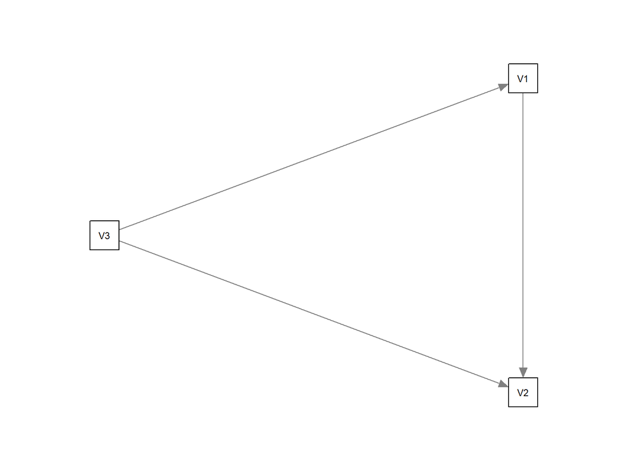

# SEM diagram for a more complex model

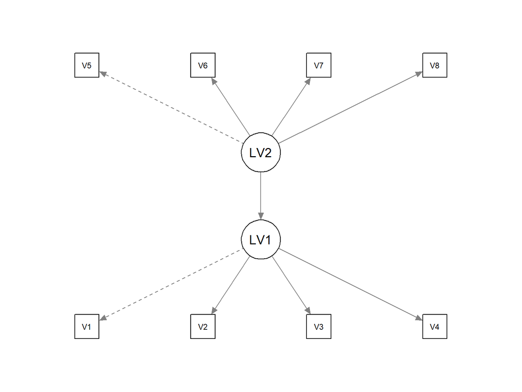

# BREAK 1

- Time for a pause
- Quiz question:
  - Which of these are differences between an EFA and a CFA:
    - 1. EFA only involves observed variables but CFA involves both observed and latent variables
    - 2. EFA estimates all possible loadings but CFA usually only estimates some
    - 3. EFA can include multiple latent variables but CFA can only include one
    - 4. CFA tests causality while EFA can only test correlation

# Welcome back 1

- Welcome back!
- The answer to the quiz question is…
  - 1. EFA only involves observed variables but CFA involves both observed and latent variables
  - 2. **EFA estimates all possible loadings but CFA usually only estimates some**
  - 3. EFA can include multiple latent variables but CFA can only include one
  - 4. CFA tests causality while EFA can only test correlation

# The CFA model

[figure not shown]

# The parameters of a CFA

# Model specification

- Defining the model we want to test
  - i.e., which **parameters** do we want to estimate?
    - How many factors?
    - Which items do we think go with which factors?
    - Are the factors correlated?
- Based on theory or past research (e.g., previous EFAs)

# Latent variable scaling

- Latent variable scaling is a key aspect of model specification
- Latent variables have no inherent scale, so we have to define one
- Two commonly used scaling methods:
  - Method 1: Fix the variance of each latent variable to 1
  - Method 2: Fix one factor loading for each latent variable to 1
- Note that the necessity of scaling also applies to the residual factors
  - Typically uses Method 2

# Scaling the latent variables by fixing factor variances

[figure not shown]

# Scaling the latent variables by fixing factor loadings

[figure not shown]

# Model identification

- More generally, we need to ensure that the model we specify is **identified**
- Identification concerns the number of ‘knowns’ versus ‘unknowns’
- There must be more knowns than unknowns in order to be able to test a CFA
- In CFA, the knowns are variances and covariances of the observed variables
- The unknowns are the parameters we want to estimate
- **Degrees of freedom** are the difference between knowns and unknowns

# Levels of identification

- There are three levels of identification:
- **Under-identified** models: have < 0 degrees of freedom
- **Just Identified** models: have 0 degrees of freedom
- **Over-Identified** models: have > 0 degrees of freedom

# Model identification illustration

# The number of knowns

- To ensure model identification, we need to know the number of knowns
- We can calculate the knowns by:

  $$\frac{\left(k+1 \right)\left(k \right)}{2}$$
- where *k* is the number of observed variables.

# The number of knowns

- This is the number of unique elements in the variance-covariance matrix for our observed variables
  - e.g., if we had three observed variables:

```r
round(cov(Three.variables),2)
```

```
##      V1   V2   V3
## V1 1.05 0.33 0.42
## V2 0.33 1.03 0.65
## V3 0.42 0.65 1.01
```

- We have 6 unique elements (3 variances and 3 covariances)

# Implications for CFA

- We usually need a minimum of three observed variables for a just identified model

[figure not shown]

# BREAK 2

- Time for a pause
- Quiz question:
  - A CFA model with 3 degrees of freedom would be best described as:
    - Under-identified
    - Over-identified
    - Just identified
    - Negatively identified

# Welcome back 2

- Welcome back!
- The answer to the quiz question is:
  - A CFA model with 3 degrees of freedom would be best described as:
    - Under-identified
    - **Over-identified**
    - Just identified
    - Negatively identified

# Model estimation

- After we have specified our model (& checked it is identified) we proceed to **estimation**
- Model estimation refers to finding the ‘best’ values for the unknown parameters

# Specifying which parameters to estimate…

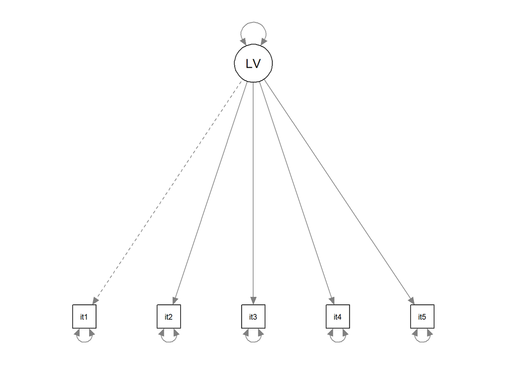

# Finding the parameter values

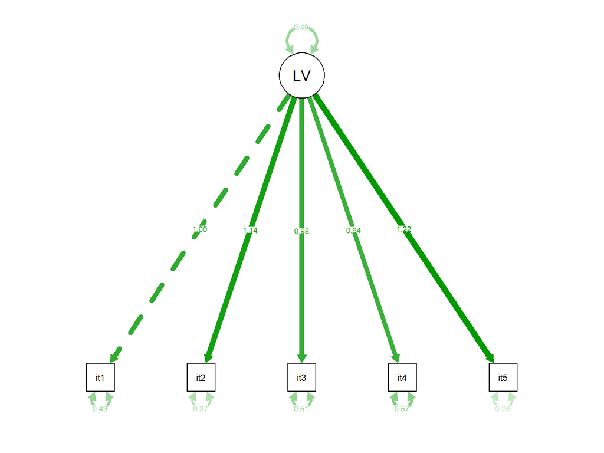

# Maximum likelihood estimation

- Maximum likelihood estimation is most commonly used
- Finds the parameters that maximise the likelihood of the data
- Begins with a set of starting values
- Iterative process of improving these values
  - i.e. to minimise the difference between the sample covariance matrix and the covariance matrix implied by the parameter values
- Terminates when the values are no longer substantially improved across iterations
  - At this point **convergence** is said to have been reached

# No convergence?

- Sometimes estimation fails
- Common reasons are:
  - The model is not identified
  - The model is very mis-specified
  - The model is very complex so more iterations are needed than the program default

# Maximum likelihood estimation assumptions

- Large sample size
- Multivariate normality
- Variables are on a continuous scale

# Alternative estimators

- Robust maximum likelihood estimation
  - For non-normal data
- Weighted least squares, unweighted least squares or diagonally weighted least squares
  - For ordinal data

# BREAK 3

- Time for a pause
- Quiz question:
  - Which of these is most likely to result in a model failing to converge using maximum likelihood estimation:
    - Model under-identification
    - Skewed variables
    - A sample size of only n=100
    - Ordinal variables with 5 response options

# Welcome back 3

- Welcome back!
- The answer to the quiz question is…
  - Which of these is most likely to result in a model failing to converge using maximum likelihood estimation:
    - **Model under-identification**
    - Skewed variables
    - A sample size of only n=100
    - Ordinal variables with 5 response options

# Model evaluation

- Once the model has been evaluated, we ask: *how good is the model?*
  - Global fit
  - Local fit

# Global fit

- $\chi^2$
  - When we use maximum likelihood estimation we obtain a $\chi^2$ value for the model
  - This can be compared to a $\chi^2$ distribution with degrees of freedom equal to our model degrees of freedom
  - Statistically significant $\chi^2$ suggests the CFA model does not do a good job of reproducing the observed variance-covariance matrix
- However, $\chi^2$ does not work well in practice
  - Leads to the rejection of models that are only trivially mis-specified

# Alternatives to $\chi^2$

# Incremental fit indices

- Compares the model to a more restricted baseline model
  - Usually an ‘independence’ model where all observed variable covariances fixed to 0
- Comparative fit index (**CFI**)
  - ranges between 0 and 1 with 1=perfect fit
  - values > .95 considered good
- Tucker-Lewis index (**TLI**)
  - includes a parsimony penalty
  - values >.95 considered good

# Local fit

- It is also possible to examine **local** areas of mis-fit
- **Modification indices** estimate the improvement in $\chi^2$ that could be expected from including an additional parameter
  - e.g., a cross-loading, residual covariance or latent variable covariance
- **Expected parameter changes** estimate the value of the parameter were it to be included

# Making model modifications

- Modification indices and expected parameter changes can be helpful for identifying how to improve the model
- However:
  - Modifications should be made iteratively
  - Don’t go overboard: may just be capitalising on chance
  - Make sure the modifications can be justified on substantive grounds
  - Be aware that this becomes an exploratory modeling practice
  - Ideally replicate the new model in an independent sample

# Other considerations in model evaluation

- Ideally:
  - Factor loadings should be statistically significant
  - Standardised factor loadings should be >|.30|
  - Else some items/parameters could be trimmed from the model
  - (with the same caveats as on previous slide)
- Check for **Heywood cases**
  - Parameter estimates that are outside the permissable range
  - E.g., correlations >1, negative residual variances
  - May require modifications to the model to address

# BREAK 4

- Time for a pause
- Quiz question
- Which of these fit indices compares a CFA model fit to an ‘independence model’ fit:
  - Comparative fit index (CFI)
  - Root Mean Square Error of Approximation (RMSEA)
  - Standardised Root Mean Square Residual (SRMR)
  - Chi-square

# Welcome back 4

- Welcome back!
- Which of these fit indices compares a CFA model fit to an ‘independence model’ fit:
  - **Comparative fit index (CFI)**
  - Root Mean Square Error of Approximation (RMSEA)
  - Standardised Root Mean Square Residual (SRMR)
  - Chi-square

# Interpreting a CFA

- To aid interpretation we can request a fully **standardised solution**
- Converts loadings/covariances to a correlation metric
- Thereafter, the interpretation is similar to EFA:
  - Loadings tell us strength of association between latent factor and items
  - Factor correlations tell us how strongly associated latent factors are

# Conducting a CFA model using lavaan

- Lavaan = **La**tent **Va**riable **An**alysis
- Used to specify and estimate latent variable models
- Three steps:

```r
#step 1: specify the model

model<-'LV=~V1+V2+V3+V4'
  # we write the model using lavaan syntax enclosed in single quote marks

#step2: estimate the model

model.est<-cfa(model=model, data=df)
   # 'model= ' refers to a lavaan syntax object with the model specification
   # 'data= ' gives name of the dataframe in which to find the variables
#step3: inspect the results

summary(model.est)
    # the summary function shows us output from a fitted model
```

# Model specification

- Specification uses lavaan syntax:

```r
# simple regression model

Regression<-'DV~IV'

# multiple regression model

Multiple.regression<-'DV~IV1+IV2+IV3'

#covariance between two variables

Covariance<-'V1~~V2'

#latent factor specification

CFA<-'LV=~V1+V2+V3+V4'
```

# Model specification for our aggression example

1. I hit someone
2. I kicked someone
3. I shoved someone
4. I battered someone
5. I physically hurt someone on purpose
6. I deliberately insulted someone
7. I swore at someone
8. I threatened to hurt someone
9. I called someone a nasty name to their face
10. I shouted mean things at someone

```r
agg_m<-
  'Pagg=~item1+item2+item3+item4+item5

   Vagg=~item6+item7+item8+item9+item10

   Pagg~~Vagg'
```

# Model estimation in lavaan

- To estimate the model, we then feed the object we just created into the cfa( ) function
- We also name the dataset containing the model
  - Lavaan will compute the variance-covariance matrix internally

```r
agg_m.est<-cfa(agg_m, data=agg.items)
```

# Scaling constraints

- By default, cfa( ) will scale the latent variables by fixing the first indicator for each latent factor to 1
- To override this and fix latent factor variances instead, we can write:

```r
agg_m.est<-cfa(agg_m, data=agg.items, std.lv=T)
```

# Model evaluation

- We can check the model fit using the summary( ) function:

```r
summary(agg_m.est, fit.measures=T)
```

```
## lavaan 0.6-5 ended normally after 23 iterations
##
##   Estimator                                         ML
##   Optimization method                           NLMINB
##   Number of free parameters                         21
##
##   Number of observations                          1000
##
## Model Test User Model:
##
##   Test statistic                                41.739
##   Degrees of freedom                                34
##   P-value (Chi-square)                           0.170
##
## Model Test Baseline Model:
##
##   Test statistic                              4711.354
##   Degrees of freedom                                45
##   P-value                                        0.000
##
## User Model versus Baseline Model:
##
##   Comparative Fit Index (CFI)                    0.998
##   Tucker-Lewis Index (TLI)                       0.998
##
## Loglikelihood and Information Criteria:
##
##   Loglikelihood user model (H0)             -11838.328
##   Loglikelihood unrestricted model (H1)     -11817.459
##
##   Akaike (AIC)                               23718.657
##   Bayesian (BIC)                             23821.720
##   Sample-size adjusted Bayesian (BIC)        23755.023
##
## Root Mean Square Error of Approximation:
##
##   RMSEA                                          0.015
##   90 Percent confidence interval - lower         0.000
##   90 Percent confidence interval - upper         0.029
##   P-value RMSEA <= 0.05                          1.000
```

[output cut: 30 more lines]

```
##
## Variances:
##                    Estimate  Std.Err  z-value  P(>|z|)
##    .item1             0.491    0.026   19.051    0.000
##    .item2             0.369    0.022   16.488    0.000
##    .item3             0.515    0.027   19.360    0.000
##    .item4             0.572    0.029   19.844    0.000
##    .item5             0.286    0.021   13.748    0.000
##    .item6             0.605    0.029   20.891    0.000
##    .item7             0.219    0.016   13.978    0.000
##    .item8             0.168    0.015   10.988    0.000
##    .item9             0.541    0.026   20.657    0.000
##    .item10            0.532    0.026   20.469    0.000
##     Pagg              1.000
##     Vagg              1.000
```

# Model evaluation

- We can examine local mis-specifications using the modindices() function

```r
modindices(agg_m.est, sort=T)
```

```
##      lhs op    rhs    mi    epc sepc.lv sepc.all sepc.nox
## 26  Pagg =~  item8 7.281 -0.051  -0.051   -0.051   -0.051
## 27  Pagg =~  item9 7.099  0.069   0.069    0.070    0.070
## 25  Pagg =~  item7 6.654  0.050   0.050    0.050    0.050
## 38 item1 ~~  item6 5.283 -0.044  -0.044   -0.080   -0.080
## 61 item4 ~~  item8 4.760 -0.030  -0.030   -0.096   -0.096
## 24  Pagg =~  item6 3.288 -0.050  -0.050   -0.049   -0.049
## 57 item3 ~~ item10 2.572 -0.029  -0.029   -0.056   -0.056
## 60 item4 ~~  item7 2.231  0.021   0.021    0.059    0.059
## 33  Vagg =~  item5 2.018 -0.032  -0.032   -0.032   -0.032
## 36 item1 ~~  item4 1.997 -0.028  -0.028   -0.054   -0.054
## 53 item3 ~~  item6 1.701  0.025   0.025    0.045    0.045
## 40 item1 ~~  item8 1.513  0.016   0.016    0.055    0.055
## 62 item4 ~~  item9 1.427  0.023   0.023    0.041    0.041
## 46 item2 ~~  item6 1.333 -0.020  -0.020   -0.043   -0.043
```

[output cut: 41 more lines]

# Standardised parameter estimates

- We can also inspect the standardised parameter estimates

```r
summary(agg_m.est, standardized=T)
```

```
## lavaan 0.6-5 ended normally after 23 iterations
##
##   Estimator                                         ML
##   Optimization method                           NLMINB
##   Number of free parameters                         21
##
##   Number of observations                          1000
##
## Model Test User Model:
##
##   Test statistic                                41.739
##   Degrees of freedom                                34
##   P-value (Chi-square)                           0.170
##
## Parameter Estimates:
##
##   Information                                 Expected
##   Information saturated (h1) model          Structured
##   Standard errors                             Standard
##
## Latent Variables:
##                    Estimate  Std.Err  z-value  P(>|z|)   Std.lv  Std.all
##   Pagg =~
##     item1             0.695    0.029   24.157    0.000    0.695    0.704
##     item2             0.792    0.028   28.463    0.000    0.792    0.793
##     item3             0.678    0.029   23.387    0.000    0.678    0.687
##     item4             0.656    0.030   22.003    0.000    0.656    0.655
##     item5             0.850    0.027   31.231    0.000    0.850    0.846
##   Vagg =~
##     item6             0.652    0.030   21.967    0.000    0.652    0.642
##     item7             0.873    0.025   34.276    0.000    0.873    0.881
##     item8             0.922    0.025   36.289    0.000    0.922    0.914
##     item9             0.662    0.029   23.157    0.000    0.662    0.669
##     item10            0.691    0.029   24.006    0.000    0.691    0.688
##
## Covariances:
##                    Estimate  Std.Err  z-value  P(>|z|)   Std.lv  Std.all
##   Pagg ~~
##     Vagg              0.098    0.035    2.792    0.005    0.098    0.098
##
## Variances:
##                    Estimate  Std.Err  z-value  P(>|z|)   Std.lv  Std.all
##    .item1             0.491    0.026   19.051    0.000    0.491    0.504
##    .item2             0.369    0.022   16.488    0.000    0.369    0.371
##    .item3             0.515    0.027   19.360    0.000    0.515    0.528
##    .item4             0.572    0.029   19.844    0.000    0.572    0.570
##    .item5             0.286    0.021   13.748    0.000    0.286    0.284
##    .item6             0.605    0.029   20.891    0.000    0.605    0.588
##    .item7             0.219    0.016   13.978    0.000    0.219    0.223
##    .item8             0.168    0.015   10.988    0.000    0.168    0.165
##    .item9             0.541    0.026   20.657    0.000    0.541    0.552
##    .item10            0.532    0.026   20.469    0.000    0.532    0.527
##     Pagg              1.000                               1.000    1.000
##     Vagg              1.000                               1.000    1.000
```

# Visualising the model

- Sempaths() from the semPlot package can be used to visual a model as a SEM diagram

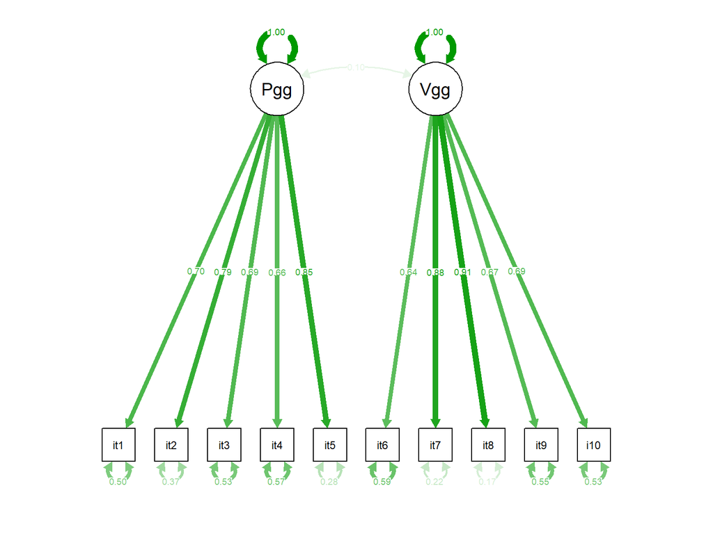

```r
semPaths(agg_m.est, what='stand')
```

# Writing up a CFA model

- Methods
  - Model(s) being tested
  - Scaling /identifcation method
  - Estimation method
  - Criteria that used to judge fit
- Results
  - Model fit ($\chi^2$ test, CFI, TLI, RMSEA, SRMR)
  - Any modifications made and why
  - Model parameters (in a SEM diagram or table)

# Cautions regarding CFA

- Good fit doesn’t guarantee that the model is ‘correct’
- Be careful about ‘reifying’ latent variables
- Even when there are no common factors, CFA models can fit well

# Summary

CFA involves testing a hypothesised factor structure

- Specifying a model
  - Identification and scaling
- Estimating that model
  - e.g., maximum likelihood estimation
- Seeing how well that model fits the data
  - Global and local fit
- Interpreting the model